# UT comparison: T (WT) vs U (UBL5 knockout)

## 8 Gene-level explorer

Each panel shows **isoform fraction before and after LPS in both genotypes**, for every isoform of the gene — not only the ones that reached significance. Open points are LPS−, filled are LPS+, and the arrow is the shift; small grey points are individual replicates. Green arrows are significant switches, purple are isoforms that were quantified but did not switch. Novel isoforms are tagged `(PB)`.

This is what the unfiltered context layer buys: for a gene called switching in only one genotype, the other panel used to be empty. It now shows whether the transcript is present and simply holds its ratio, or is absent altogether.

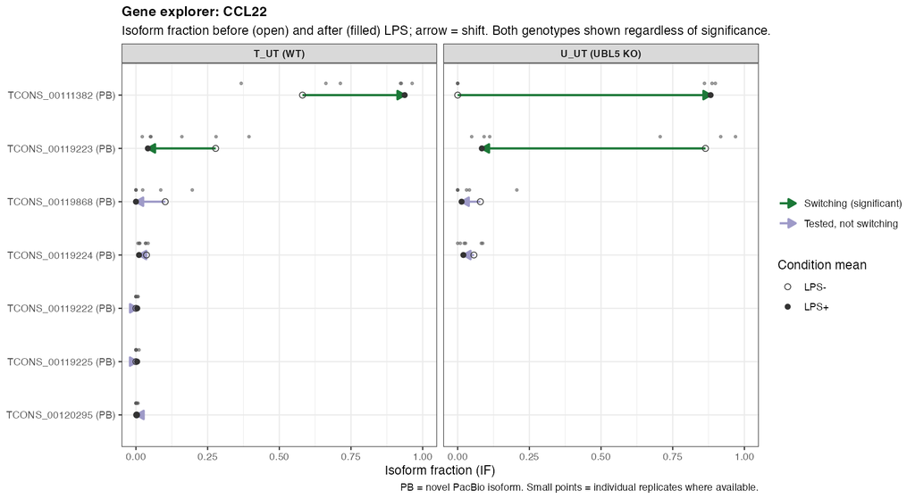

Gene explorer panels (subset by overlap class)

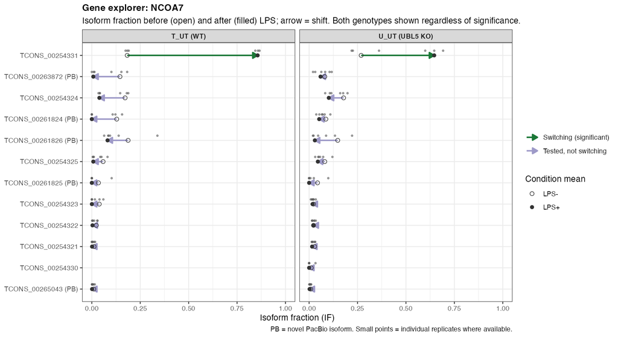

Gene explorer panels (subset by overlap class)

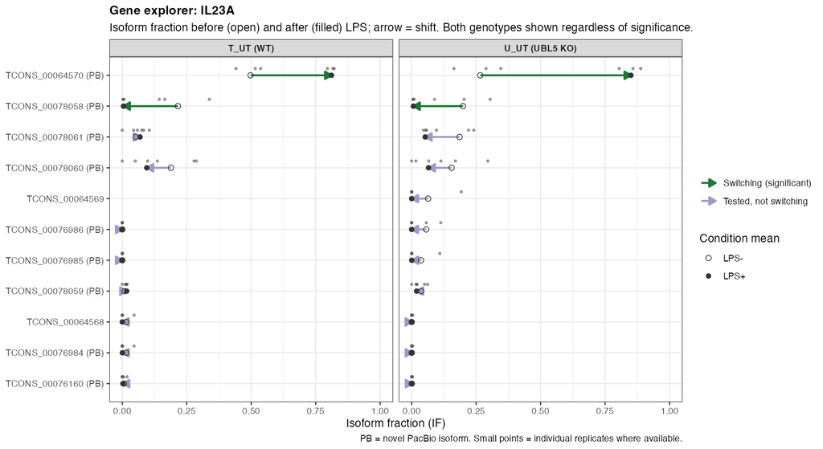

Gene explorer panels (subset by overlap class)

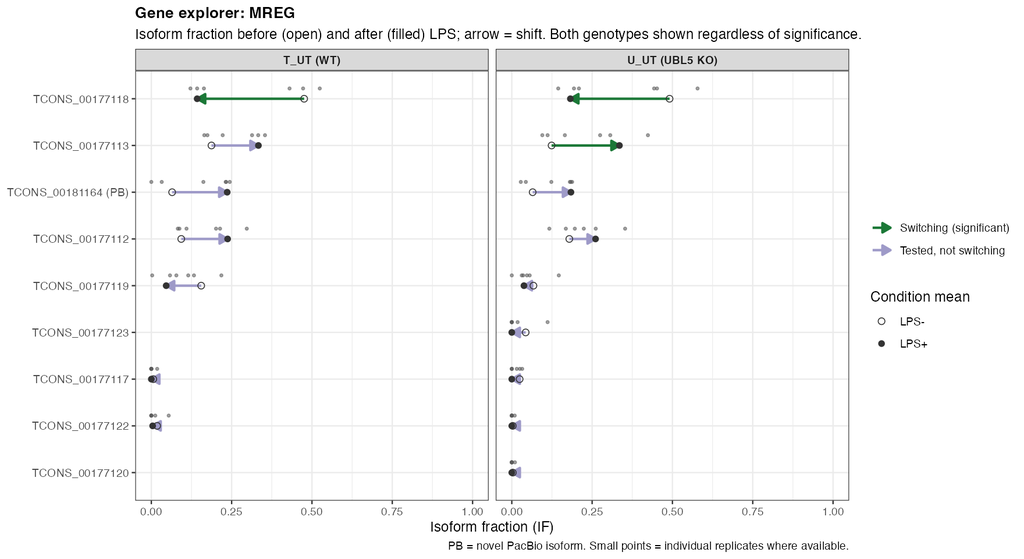

Gene explorer panels (subset by overlap class)

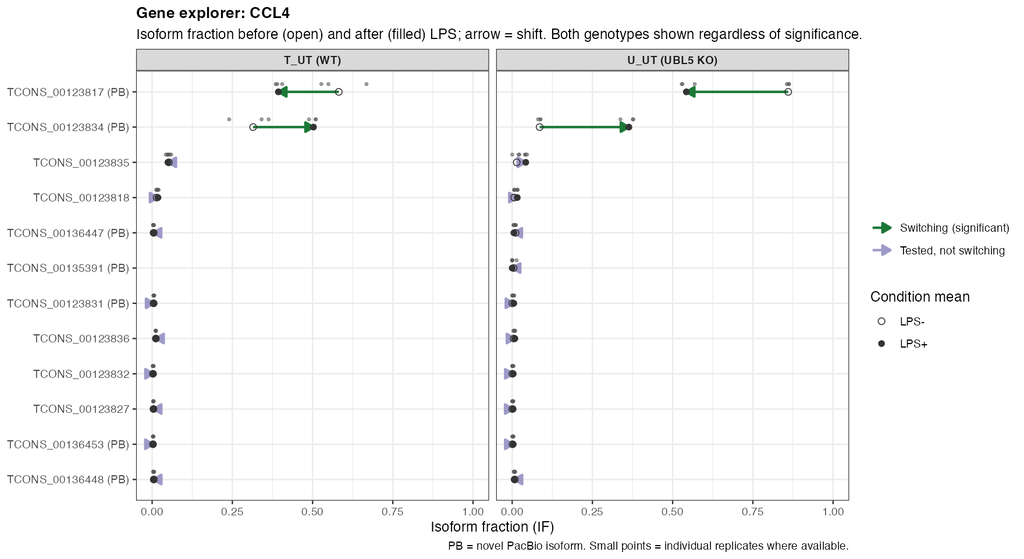

Gene explorer panels (subset by overlap class)

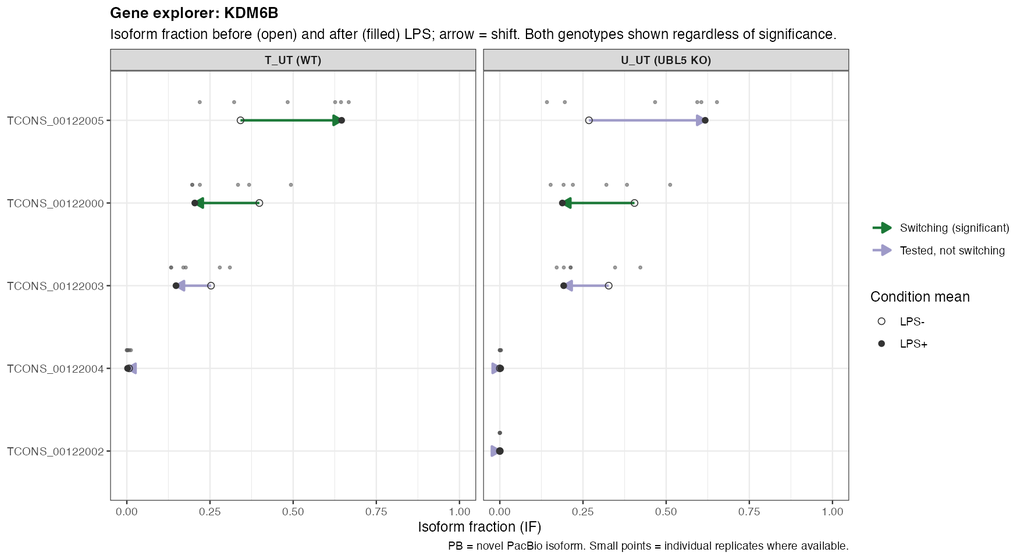

Gene explorer panels (subset by overlap class)

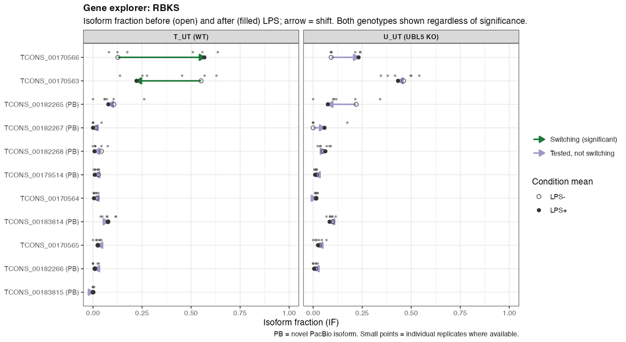

Gene explorer panels (subset by overlap class)

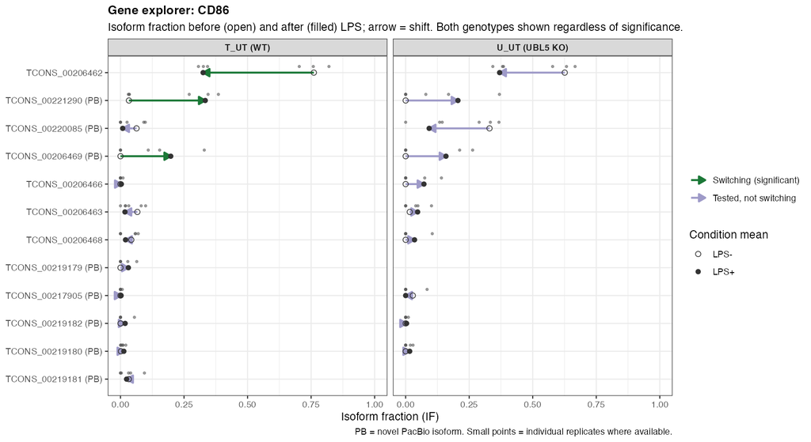

Gene explorer panels (subset by overlap class)

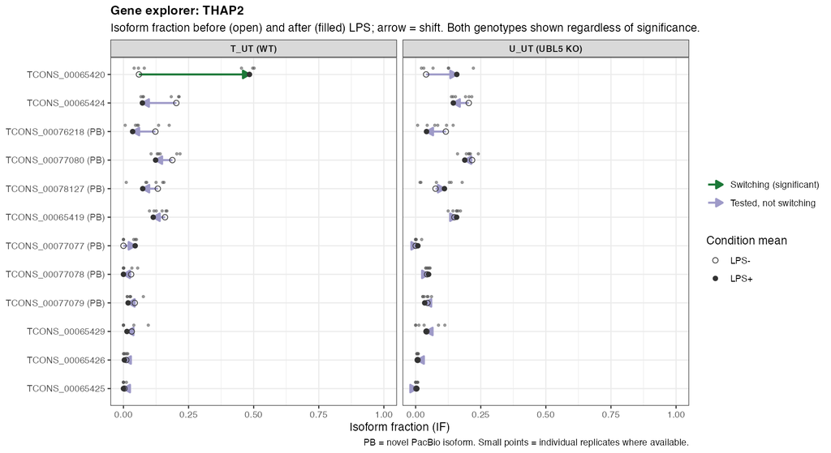

Gene explorer panels (subset by overlap class)

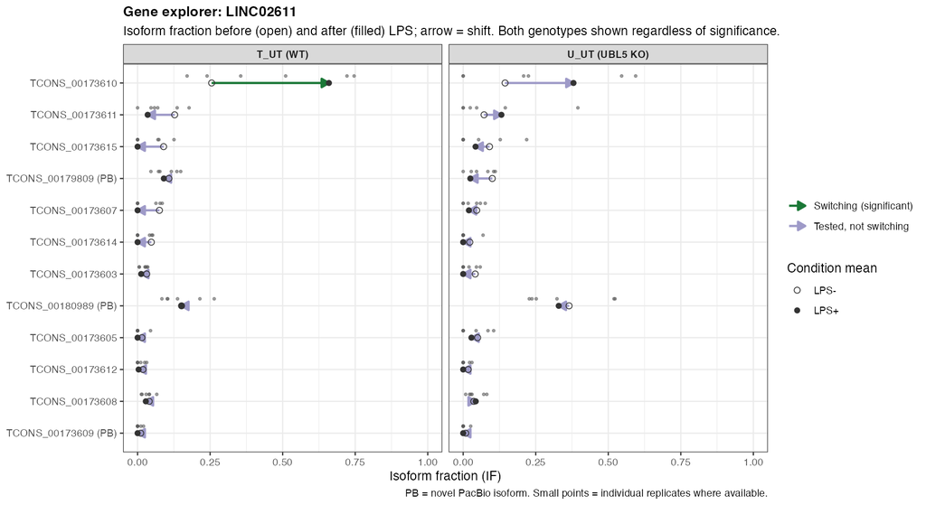

Gene explorer panels (subset by overlap class)

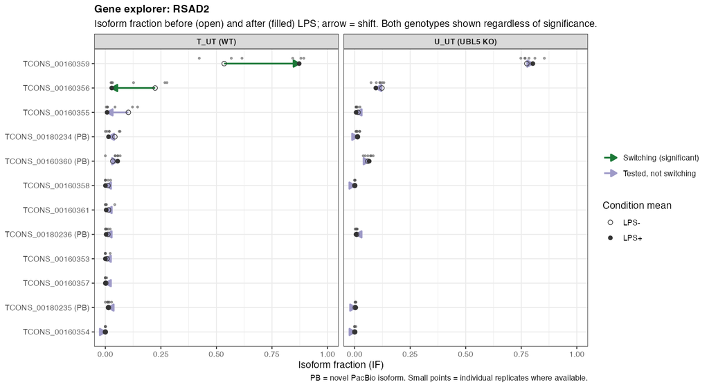

Gene explorer panels (subset by overlap class)

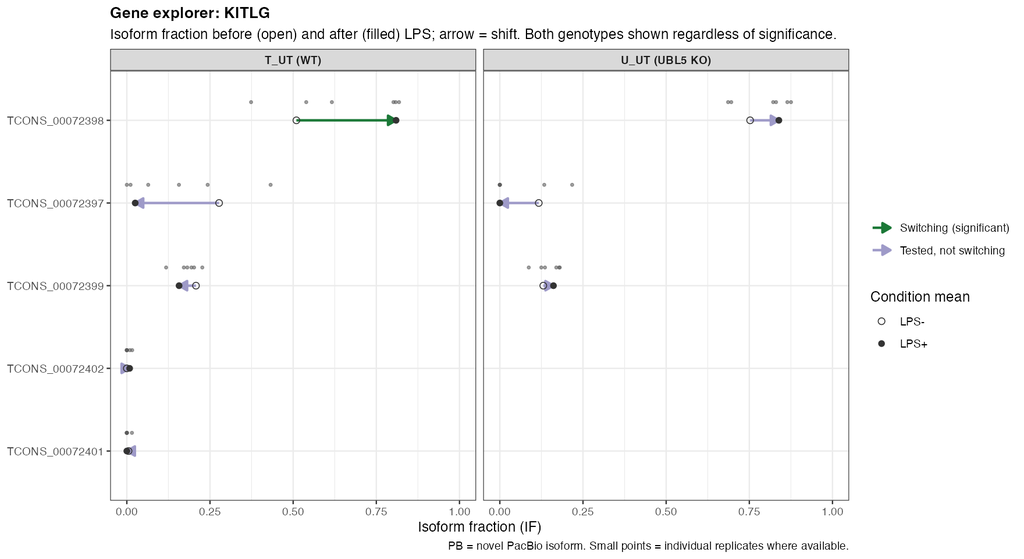

Gene explorer panels (subset by overlap class)

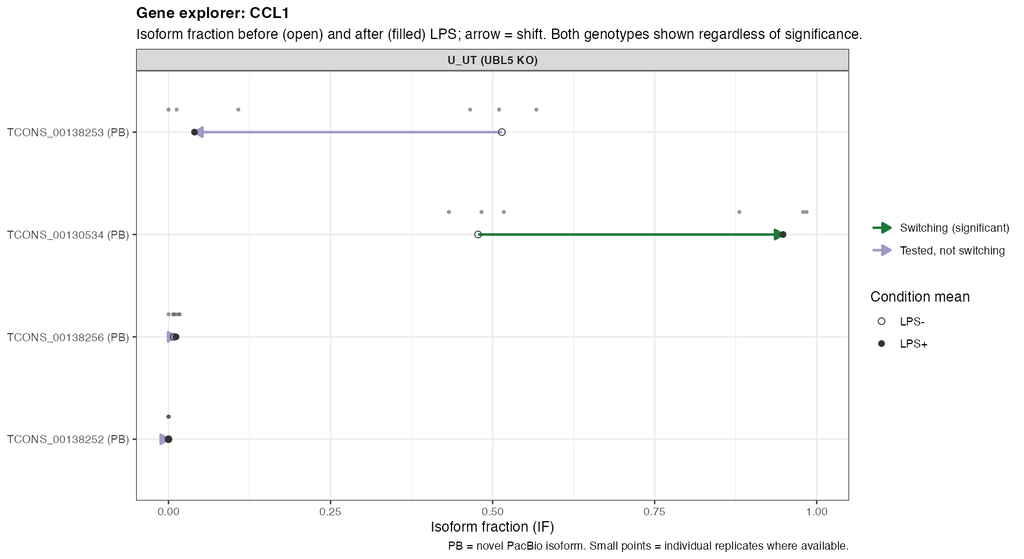

Gene explorer panels (subset by overlap class)

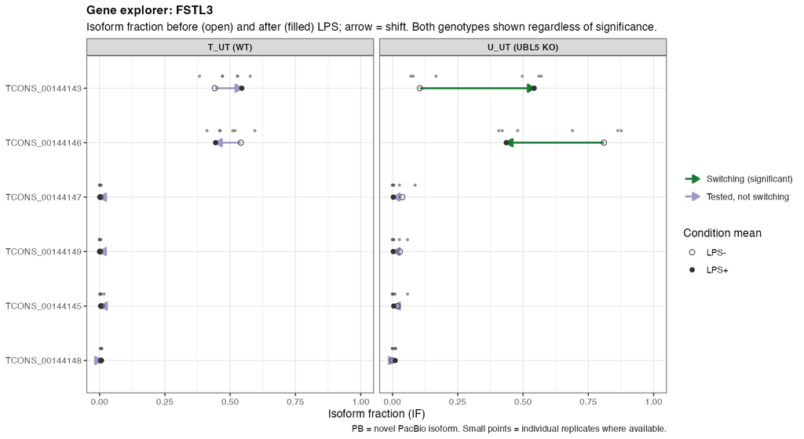

Gene explorer panels (subset by overlap class)

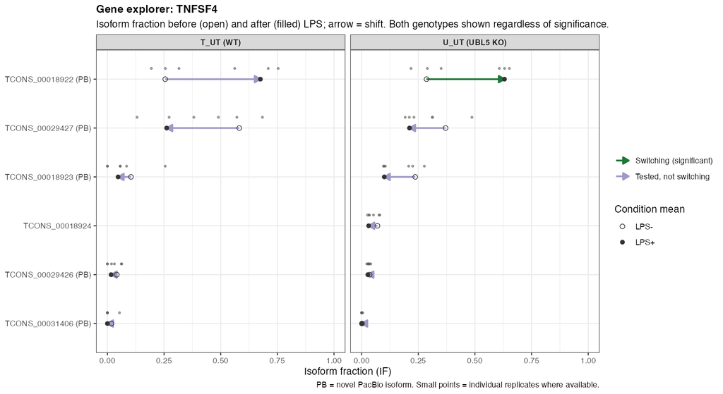

Gene explorer panels (subset by overlap class)

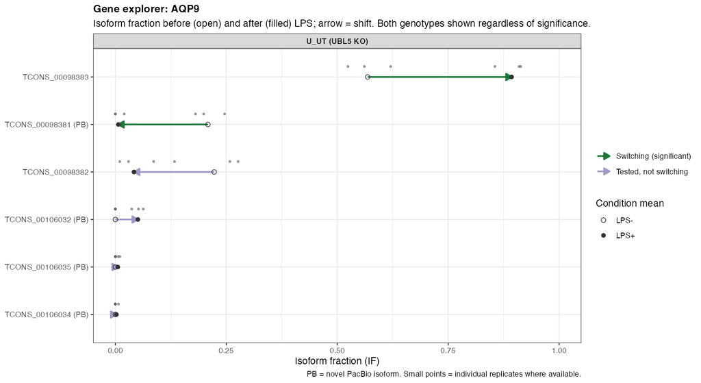

Gene explorer panels (subset by overlap class)

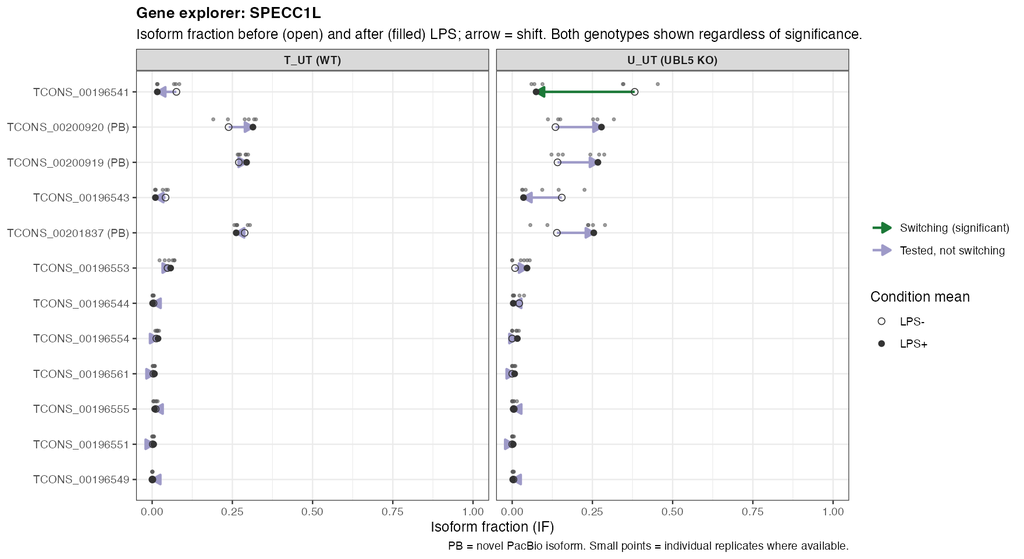

Gene explorer panels (subset by overlap class)

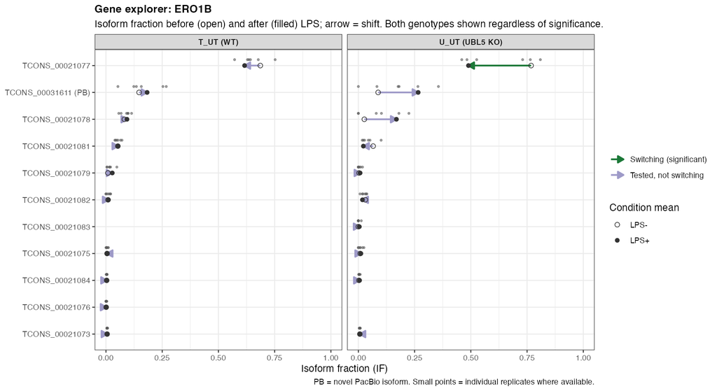

Gene explorer panels (subset by overlap class)

Gene explorer figures included above

| gene_name | overlap_class | figure | T_max_abs_dif | U_max_abs_dif |
| --- | --- | --- | --- | --- |
| CCL22 | Shared (T and U) | gene_explorer_Shared_T_and_U__01_CCL22.png | 0.3563 | 0.8822 |
| NCOA7 | Shared (T and U) | gene_explorer_Shared_T_and_U__02_NCOA7.png | 0.6734 | 0.3771 |
| IL23A | Shared (T and U) | gene_explorer_Shared_T_and_U__03_IL23A.png | 0.3136 | 0.5845 |
| MREG | Shared (T and U) | gene_explorer_Shared_T_and_U__04_MREG.png | 0.3330 | 0.3087 |
| CCL4 | Shared (T and U) | gene_explorer_Shared_T_and_U__05_CCL4.png | 0.1882 | 0.3175 |
| KDM6B | Shared (T and U) | gene_explorer_Shared_T_and_U__06_KDM6B.png | 0.3039 | 0.2169 |
| RBKS | T-only | gene_explorer_T_only_13_RBKS.png | 0.4408 | NA |
| CD86 | T-only | gene_explorer_T_only_14_CD86.png | 0.4357 | NA |
| THAP2 | T-only | gene_explorer_T_only_15_THAP2.png | 0.4244 | NA |
| LINC02611 | T-only | gene_explorer_T_only_16_LINC02611.png | 0.4042 | NA |
| RSAD2 | T-only | gene_explorer_T_only_17_RSAD2.png | 0.3374 | NA |
| KITLG | T-only | gene_explorer_T_only_18_KITLG.png | 0.2996 | NA |
| CCL1 | U-only | gene_explorer_U_only_25_CCL1.png | NA | 0.4704 |
| FSTL3 | U-only | gene_explorer_U_only_26_FSTL3.png | NA | 0.4372 |
| TNFSF4 | U-only | gene_explorer_U_only_27_TNFSF4.png | NA | 0.3440 |
| AQP9 | U-only | gene_explorer_U_only_28_AQP9.png | NA | 0.3243 |
| SPECC1L | U-only | gene_explorer_U_only_29_SPECC1L.png | NA | 0.3073 |
| ERO1B | U-only | gene_explorer_U_only_30_ERO1B.png | NA | 0.2784 |

## 9 Switch plots (showcase)

ISA `switchPlot` panels (gene symbols + PB labels when available).

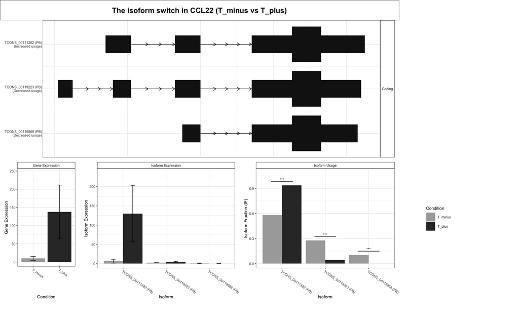

Showcase switchPlots for shared / T-only / U-only genes

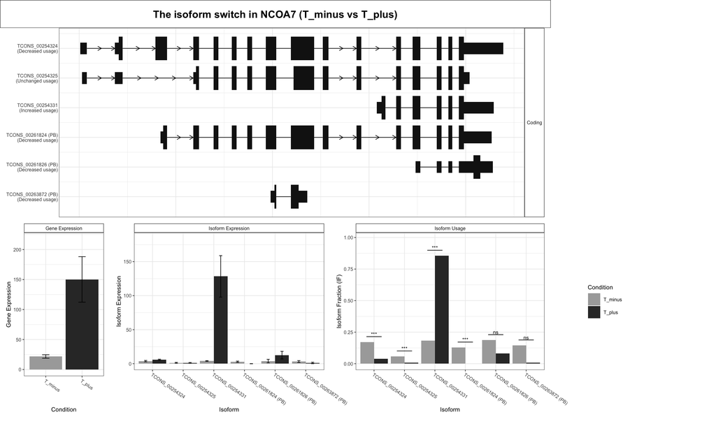

Showcase switchPlots for shared / T-only / U-only genes

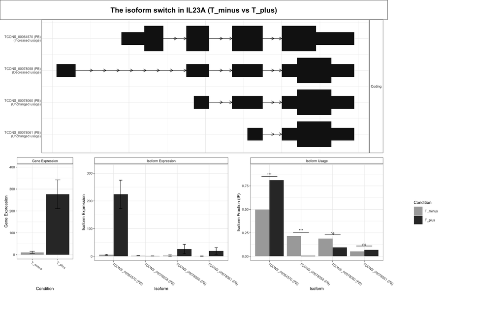

Showcase switchPlots for shared / T-only / U-only genes

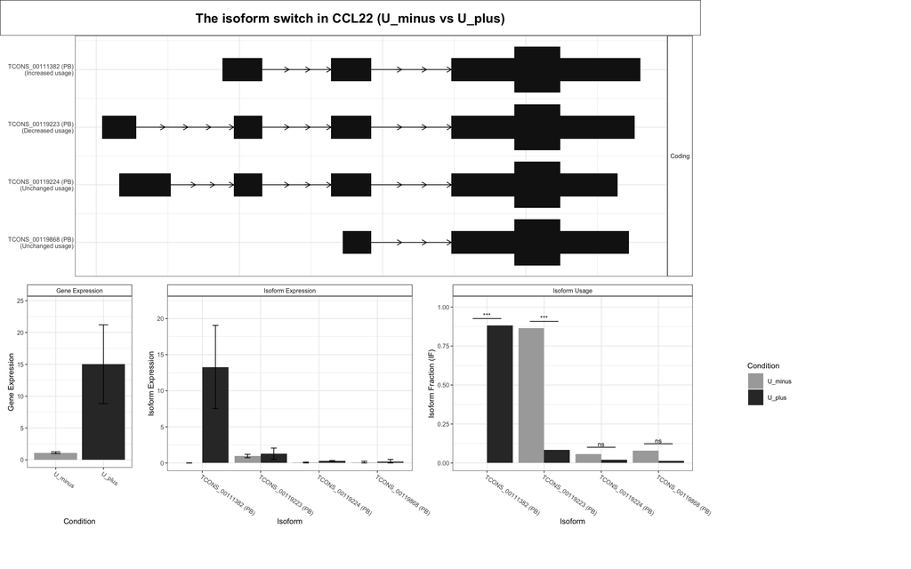

Showcase switchPlots for shared / T-only / U-only genes